# STAT509-001-HW4-Xinye Xu

## Q1

3. Exercise 7 on page 181 in Ruppert/Matteson. Hint: Use eigen command in R to carry out eigenvalue/vector analysis of the matrix, and find a vector w so that formula for the variance of w⊤X would be negative showing a contradiction if this really were a covariance matrix for

Assumed a = 0, for Matrix Y, based on eigen command, there is an negative eigenvalue. and from 7.7 for Var(w-transpose * Y) = w-tran * Y * w, which should be non-negative. Then the Y matrix should be positive dedefinite. Notice that covariance matrix is symmetric, and the symmetric matrix A is said positive semidefinite (A ≥ 0) if all its eigenvalues are non negative. So a should be zero. We can also have the same conclusion when w is set to be the following, the Var(w-transpose * Y) is negative, which breaks the common sense.

```r
m = matrix(c(1, 0.9, 0, 0.9, 1, 0.9, 0, 0.9, 1), nrow = 3)
eigen(m)
```

```
## eigen() decomposition
## $values
## [1]  2.2727922  1.0000000 -0.2727922
##
## $vectors
##           [,1]          [,2]       [,3]
## [1,] 0.5000000 -7.071068e-01  0.5000000
## [2,] 0.7071068 -8.722736e-16 -0.7071068
## [3,] 0.5000000  7.071068e-01  0.5000000
```

```r
w = matrix(c(0.5000000, -7.071068e-01, 0.5000000), nrow = 3)
t(w)  %*%  m %*% w
```

```
##            [,1]
## [1,] -0.2727922
```

## Q2

Suppose R1.R2 are returns on an asset, and suppose that E(R1) = .02,E(R2) = .04, Var(R1) = (.03)2, Var(R2) = (.06)2, and Corr(R1, R2) = 0.5.

1. What are E(0.6R1 + 0.4R2) = 0.028 and Var(0.6R1 + 0.4R2) = 0.001332

```r
0.6 * 0.02 + 0.4 * 0.04
```

```
## [1] 0.028
```

```r
sigma_1 = 0.03
sigma_2 = 0.06
0.6^2 * sigma_1^2 + 0.4^2 * sigma_2^2 + 2 * 0.6 * 0.4 * 0.5 * (sigma_1 * sigma_2)
```

```
## [1] 0.001332
```

2. For what value of w is Var(w · R1 + (1 − w) · R2) minimized? Why would it be useful to minimize Var(w · R1 + (1 − w) · R2)?

Var(w * R1 + (1 − w) · R2) = w^2 * (0.03)^2 + (1 − w)^2 * (0.06)2 +2 * w * (1−w) * 0.5 * 0.03 * 0.06 Then, take the first derivative equal to zero: 0.03^2 * w -(1-w) * 0.06^2 + (1-2w) * 0.5 * 0.03 * 0.06 = 0 So the weight for R1 is 100% and weight for R2 is 0, then variance will be minimized. The idea for w is important is that adjustment of it can help whole portfolio reduce the volatility, or standard deviation. The minimal standard deviation for the return of this portfolio is (0.03)

```r
w = (sigma_2^2 - 0.5 * sigma_1 * sigma_2) / (sigma_1^2 + sigma_2^2 - 2*0.5*sigma_1*sigma_2)
w
```

```
## [1] 1
```

```r
sigma_1^2
```

```
## [1] 9e-04
```

3. Assuming a portfolio of a $1 million, and a multivariate normal distribution for R1 and R2, find the value w that minimizes the expected shortfall associated with VaR at q = .005 and why might that be useful? Also, report the associated VaR with this portfolio.

Hints: Note that the random variable [wR1 + (1 − w)R2] is normally distributed for any w, and it will be easiest to use R-package – the solution can be approximate, i.e., accurate to .01.

```r
set.seed(123)
weight = seq(0,1,0.01)  # accurate to .01.
n = length(weight)
VaRv = rep(0,n)
shortfall = rep(0,n)
quantv = rep(0,n)
ER1 = 0.02
ER2 = 0.04
VarR1 = sigma_1^2
VarR2 = sigma_2^2
Cov = 0.5 * sigma_1 * sigma_2;
mu = weight * ER1+(1-weight)*ER2
sigma = sqrt(weight^2*VarR1 +(1-weight)^2*VarR2+2*weight*(1-weight)*Cov)

randnorm = rnorm(100000,0,1) # using same rnorm to simulate tail return for all i
for(i in 1:n){
  quantv[i] = qnorm(0.005,mu[i],sigma[i]) # VaR at q = .005
  VaRv[i] = -quantv[i]
  randnorm_value = mu[i] + sigma[i] * randnorm
  shortfall[i] = -mean(randnorm_value[randnorm_value < quantv[i]])
}

which.min(shortfall) # 93
```

```
## [1] 93
```

```r
print(VaRv[which.min(shortfall)])
```

```
## [1] 0.05641319
```

```r
print(shortfall[which.min(shortfall)])
```

```
## [1] 0.06591467
```

```r
print(VaRv[which.min(shortfall)]*1000000)
```

```
## [1] 56413.19
```

```r
print(shortfall[which.min(shortfall)]*1000000)
```

```
## [1] 65914.67
```

```r
which.min(VaRv) # 92
```

```
## [1] 92
```

```r
print(VaRv[which.min(VaRv)])
```

```
## [1] 0.05640813
```

```r
print(shortfall[which.min(VaRv)])
```

```
## [1] 0.06593336
```

```r
print(VaRv[which.min(VaRv)]*1000000)
```

```
## [1] 56408.13
```

```r
print(shortfall[which.min(VaRv)]*1000000)
```

```
## [1] 65933.36
```

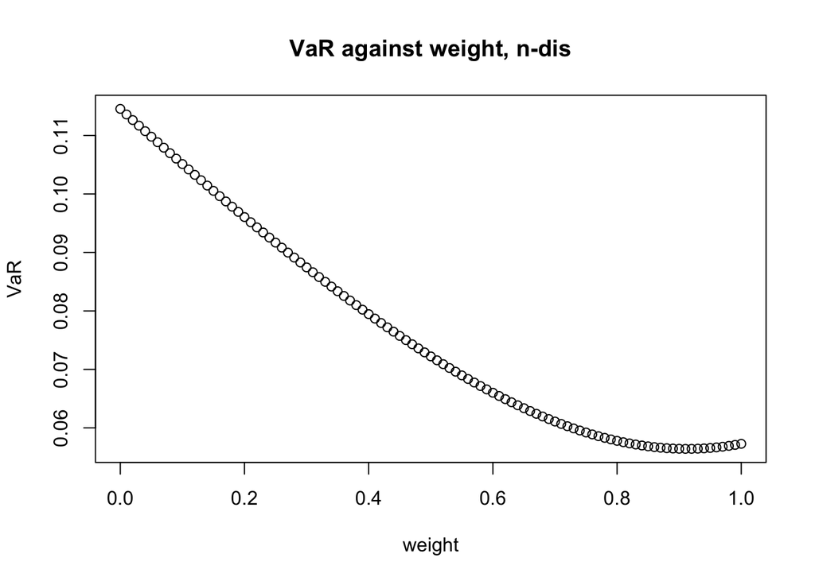

```r
plot(weight, VaRv,xlab = 'weight',ylab='VaR',main='VaR against weight, n-dis')
```

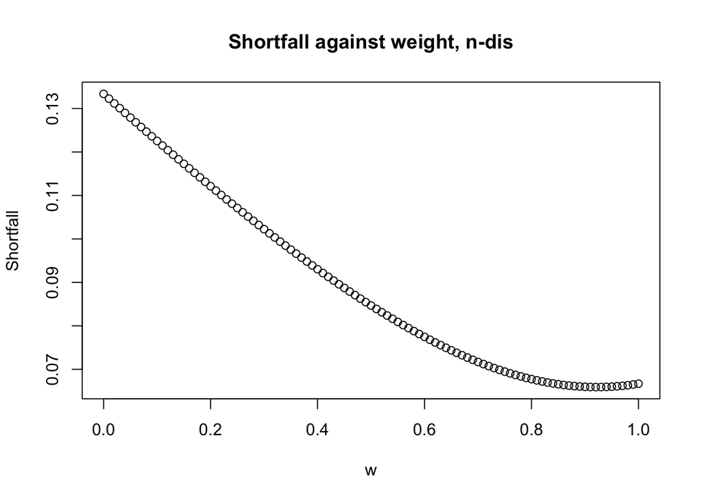

```r
plot(weight, shortfall,xlab = 'w', ylab='Shortfall', main='Shortfall against weight, n-dis')
```

4. Repeat the above if have multi-variate t-distribution for R1 and R2, with ν = 6.